# Metrics for the Data Management Campus modules

2026-06-30

This document loads and visualizes data on the use of modules from the Data Management Campus.  
The data are obtained from four sources: OpenLearnity, Matomo (metrics on the OpenLearnity modules), Google Analytics (metrics on the ORD Portal), and Zenodo OER.  
A list of the variables used in the analysis is provided below.

##### 1. Number of logged-in users per week for each module in OpenLearnity

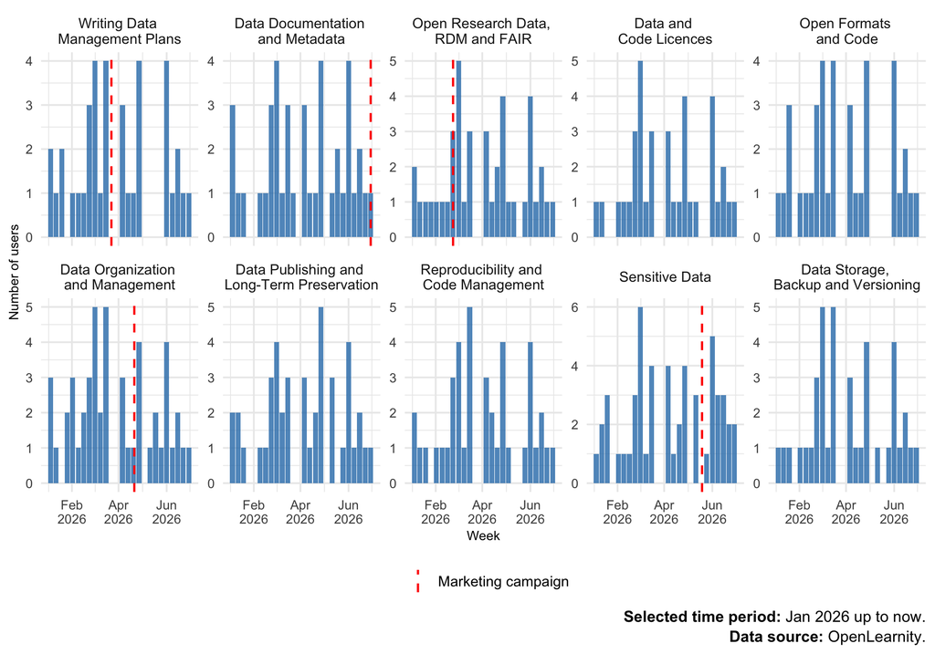

Figure 1 shows weekly user activity across modules based on OpenLearnity enrollment data.  
Blue bars represent the *logged_users_week* variable (number of unique users logging in per module each week).  
Weekly user activity is generally low, ranging from 0 to about 6 users per week depending on the module, with no strong differences in magnitude over time.  
Red dashed lines indicate the timing of the marketing campaign, corresponding to the week when the modules were advertised on ETH Campus Channel screens. No systematic change in activity is visible around the campaign period.

##### 2. User behaviour from Open Learnity and Matomo.

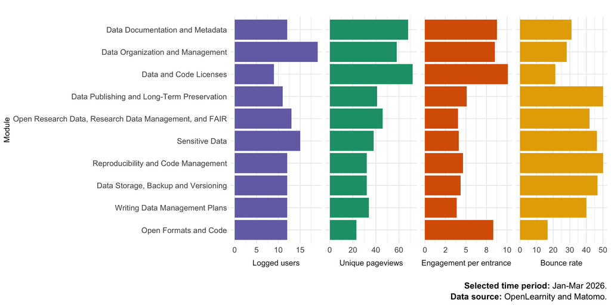

Figure 2 shows user behaviour across modules using OpenLearnity user data and Matomo analytics. Four indicators are displayed per module: *logged_users* (Open Learnity enrollment), *unique_pageviews*, *engagement_per_entrance*, and *bounce_rate* (Matomo metrics).

The four metrics together describe different dimensions of user behaviour:  
Logged users represent the number of participants enrolled in each module.  
Unique pageviews refer to the number of distinct page views of the module’s “About” page (counted once per session).  
Engagement per entrance is the average number of user interactions after sessions start on the “About” page of a module. This serves as a proxy for content depth and user interest.  
Bounce rate is the proportion of single-page sessions with no further interaction.

Best-performing module:  
The Data and Code Licenses module shows the strongest overall engagement in the dataset. It combines a relatively high number of unique pageviews (72) with the highest engagement per entrance (10.1 actions per session), indicating that users interact intensively once they access the content. In addition, it has one of the lowest bounce rates (21%), suggesting strong user retention.

Lowest-performing module:  
The Writing Data Management Plans module shows the weakest engagement profile. Although it receives a moderate number of unique pageviews (34), it has the lowest engagement per entrance (3.87 actions per session), indicating limited interaction once users enter the module. Its bounce rate (40%) is also relatively high, suggesting that a substantial proportion of users leave without further interactions.  
Limitations:  
Data is based on the *About* pages and does not capture complete user journeys across the platform, including navigation through home pages or across modules.  
The indicators are best interpreted as proxies for interaction intensity rather than direct measures of course progression or learning outcomes.

##### 3. Page views and active users for the ORD pages in Google Analytics.

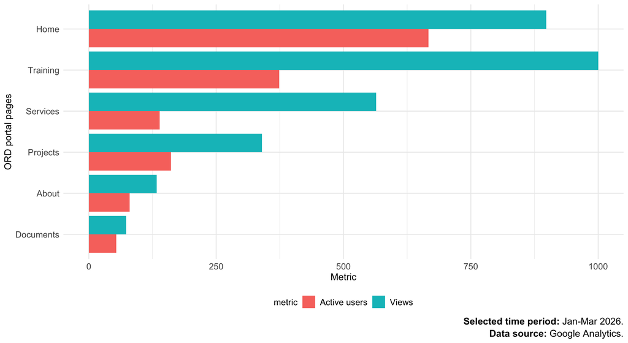

Figure 3 shows the distribution of user engagement across ORD portal pages based on Google Analytics data.  
Blue and red bars represent *views* (total number of page views; a proxy of intensity of use per page) and *active_users* (number of users whose session lasted at least 10 seconds; a proxy of reach per page) for each ORD portal page, obtained from Google Analytics.  
The Training page corresponds to the Data Management Campus and shows the highest number of views (1,000) but fewer active users (374), indicating high engagement per user (i.e., strong content usage).

##### 4. Total engagement by resource type and module in Zenodo.

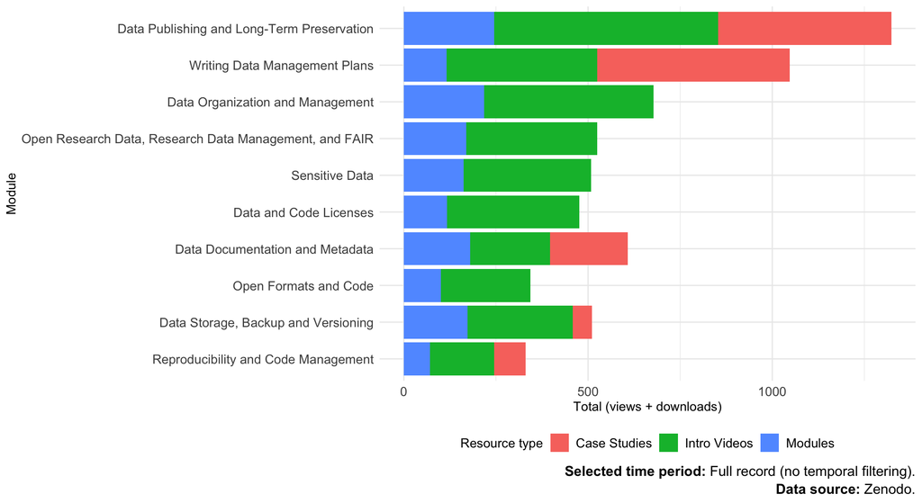

##### 5. Number of views and downloads by resource type and module in Zenodo.

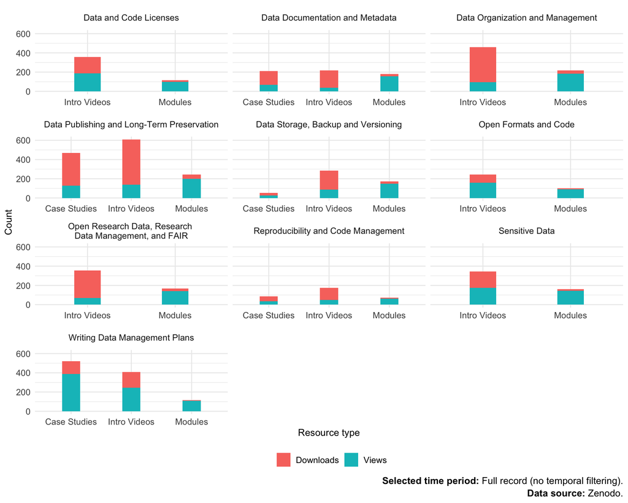

##### 6. Number of views and downloads of other resources by institution in Zenodo.

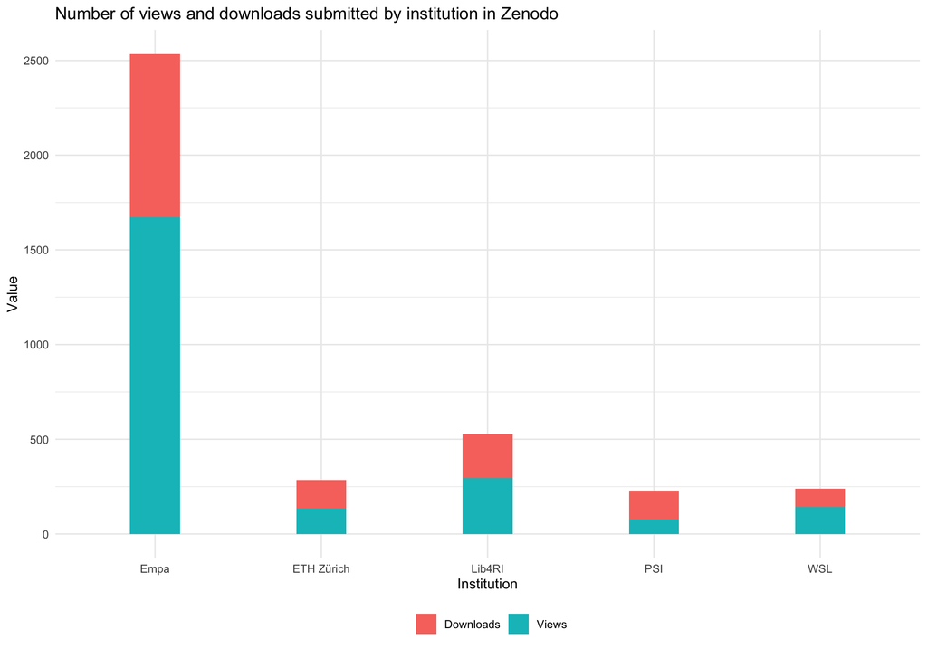

Figure 6 shows the distribution of *views* and *downloads* for other resources (i.e., non-module-related content) in Zenodo, aggregated by institution of the resource author (i.e., the institution that created the content).  
Blue and red bars represent views and downloads, respectively. Values are stacked to show total engagement per institution.  
The high number of views and downloads for EMPA corresponds to the series of video presentations on Research Data Management by Matthias Roesslein.

##### List of variables used for the analysis of Data Management Campus module usage

| indicator | source | estimation | description |
| --- | --- | --- | --- |
| **user_id** | openlearnity | direct measure | user identifier |
| **module_title** | openlearnity | direct measure | module title |
| **last_login** | openlearnity | direct measure | date of last login in the module. This variable is overwritten each time the same user logs in. |
| **logged_users_week** | openlearnity | calculated as count of unique users grouped by week (from last_login) and module | number of unique users per week for each module |
| **logged_users** | openlearnity | calculated as count of unique users per module | number of logged users per module during a specific period of time |
| **module_title** | matomo_ol | direct measure | module title |
| **unique_pageviews** | matomo_ol | direct measure | number of page views counted once per session; unique page views of the module’s “About” page |
| **entrances** | matomo_ol | direct measure | number of sessions starting on the “About” page |
| **actions_after_entry** | matomo_ol | direct measure | number of interactions (clicks, downloads, pageviews) performed after session start on the “About” page |
| **bounces** | matomo_ol | direct measure | sessions where the user leaves after viewing only one page |
| **engagement_per_entrance** | matomo_ol | calculated as actions_after_entry / entrances | average number of user interactions after session start on the “About” page |
| **bounce_rate** | matomo_ol | calculated as bounces / entrances | proportion of visits where users leave after one page |
| **page_title** | google_analytics_ord | direct measure | title of the pages in the ORD Portal |
| **views** | google_analytics_ord | direct measure | total number of page views; proxy of intensity of use per page |
| **active_users** | google_analytics_ord | direct measure | number of users who engaged with the page (session last at least 10 seconds) |
| **record_id** | zenodo | direct measure | Zenodo resource identifier |
| **resource_title** | zenodo | direct measure | resource title |
| **resource_type** | zenodo | direct measure | type of resource (lesson, presentation, video/audio) |
| **views** | zenodo | direct measure | number of times resource was viewed |
| **downloads** | zenodo | direct measure | number of times resource was downloaded |